# Assignment 3 Data Wrangling

Yaniv Bronshtein

02/15/2021

## Import the libraries

```r
library(tidyverse)
library(Lahman)
library(lubridate)
library(curl)
library(stringr)
```

## (1) We would like to create a data frame like the babynames data frame,

## but for baseball players.

### (1a) Use the Master data frame in the Lahman package to create a tibble

### with exactly the same variables as the babynames data frame, and ordered in

### the same way. You will need to use the summarize() function to get the counts

### of each name’s use. For year, use the year of birth. For name, use the first

### name (variable nameFirst). The final table should look like this

### where prop is the proportion of names in a specific birthyear)

###——————————————

### birthYear nameFirst n prop

###——————————————-

**Call group by to group master by birthYear and nameFirst** **Then, pipe the result to summarise() which will return a tibble with birthYear** **nameFirst, and a column by the name n with the counts of each grouping** **Pipe the result to mutate() and create a calculated column prop, rounding the** **value to 3 digits after the decimal** **Call arrange() to sort by the birthYear ascending**

```r
Master_t <- as_tibble(Master)
name_by_year <- Master_t %>%
  group_by(birthYear, nameFirst) %>%
  summarise(n = n()) %>%
  mutate(prop = round(n / sum(n), digits = 3)) %>%
  arrange(birthYear)
name_by_year
```

```
## # A tibble: 12,834 x 4
## # Groups:   birthYear [170]
##    birthYear nameFirst     n  prop
##        <int> <chr>     <int> <dbl>
##  1      1820 Alexander     1 1
##  2      1824 Henry         1 1
##  3      1832 Lew           1 0.333
##  4      1832 Nate          1 0.333
##  5      1832 William       1 0.333
##  6      1835 Harry         1 1
##  7      1836 Dickey        1 1
##  8      1837 Morgan        1 1
##  9      1838 Bill          1 0.333
## 10      1838 Dave          1 0.333
## # ... with 12,824 more rows
```

### (1b) In the Master dataframe, let us check whether the variable birthYear is

### consistent with the year in birthDate.

### Use a function in the lubridate package (discussed in Lecture 2) to extract

### the year from the birthDate. Call this variable birthYear2.

### In how many cases does birthYear have an “NA” entry?

### In how many cases does birthYear2 have an “NA” entry?

### In how many cases do both have “NA” entries?

### if you ignore all the cases with at least one “NA” entry

### (either in the birthYear or birthYear2 variable),

### do all the remaining cases match?

**Create a temporary dataFrame**

```r
q1_t <- Master_t %>% select(playerID, birthYear, birthDate) %>%
  mutate(birthYear2 = year(birthDate))
```

**In how many cases does birthYear have an “NA” entry**

```r
count_na_birthYear <- q1_t %>% select(birthYear) %>%
  is.na() %>% sum() %>% as.numeric()
count_na_birthYear
```

```
## [1] 115
```

**In how many cases does birthYear2 have an “NA” entry?**

```r
count_na_birthYear2 <- q1_t %>% select(birthYear2) %>%
  is.na() %>% sum() %>% as.numeric()
count_na_birthYear2
```

```
## [1] 426
```

**In how many cases do both have “NA” Entries**

```r
count_both_na <- q1_t %>%
  filter(is.na(birthYear), is.na(birthYear2)) %>% nrow() %>% as.numeric()
count_both_na
```

```
## [1] 115
```

**If you ignore all cases with at least one “NA” entry,, do all the remaining** **Cases match?** **To answer this, first create a temporary data frame neither_na_t** **Use it to compute count_neither_na and count_matching_after_neither_na**

```r
neither_na_t <- q1_t%>%
  filter(!(is.na(birthYear) | is.na(birthYear2)))
count_neither_na <- neither_na_t %>% nrow() %>% as.numeric()
count_neither_na
```

```
## [1] 19452
```

```r
count_matching_after_neither_na <- neither_na_t %>%
  filter(as.numeric(birthYear) == as.numeric(birthYear2)) %>% nrow() %>% as.numeric()
count_matching_after_neither_na
```

```
## [1] 19452
```

*As you can see based on the results, the count is the same, meaning that all* *the remaining cases match*

### (1c) Create a data frame of players showing just the playerID, first name,

### last name, given name, and career total

### (meaning, summed over all years and all stints) of games

### (that is, the G variable) according to the Fielding data frame.

**Create a tibble to store Fielding data**

```r
fielding_t <- as_tibble(Fielding)
```

**Create a variable FieldingSmall containing only playerID and G from fielding_t**

```r
FieldingSmall <- fielding_t %>% select(playerID, G)
```

**Create a variable Master_small_t containing only playerID, nameFirst, nameLast** **and name given from Master_t**

```r
Master_small_t <- Master_t %>% select(playerID, nameFirst, nameLast, nameGiven)
```

**Perform a left join between the two subset tables on the key playerID** **Then, pipe the result to group by playerID, nameFirst, nameLast, nameGiven** **Pipe the result after grouping to create a final tibble with added total games** **column**

```r
player_t <- FieldingSmall %>% left_join(Master_small_t, by = "playerID") %>%
  group_by(playerID, nameFirst, nameLast, nameGiven) %>% summarise(total_games = sum(G))
player_t
```

```
## # A tibble: 19,491 x 5
## # Groups:   playerID, nameFirst, nameLast [19,491]
##    playerID  nameFirst nameLast    nameGiven        total_games
##    <chr>     <chr>     <chr>       <chr>                  <int>
##  1 aardsda01 David     Aardsma     David Allan              331
##  2 aaronha01 Hank      Aaron       Henry Louis             3020
##  3 aaronto01 Tommie    Aaron       Tommie Lee               387
##  4 aasedo01  Don       Aase        Donald William           448
##  5 abadan01  Andy      Abad        Fausto Andres              9
##  6 abadfe01  Fernando  Abad        Fernando Antonio         384
##  7 abadijo01 John      Abadie      John W.                   12
##  8 abbated01 Ed        Abbaticchio Edward James             830
##  9 abbeybe01 Bert      Abbey       Bert Wood                 79
## 10 abbeych01 Charlie   Abbey       Charles S.               452
## # ... with 19,481 more rows
```

### (1d) Using mutate() and str_c(), add a variable to your data frame in (c) for full name by

### combining the first name and last name with a space between them.

```r
player_t <- player_t %>% mutate(fullName =
                                       str_c(nameFirst, nameLast, sep = " "))
player_t
```

```
## # A tibble: 19,491 x 6
## # Groups:   playerID, nameFirst, nameLast [19,491]
##    playerID  nameFirst nameLast    nameGiven        total_games fullName
##    <chr>     <chr>     <chr>       <chr>                  <int> <chr>
##  1 aardsda01 David     Aardsma     David Allan              331 David Aardsma
##  2 aaronha01 Hank      Aaron       Henry Louis             3020 Hank Aaron
##  3 aaronto01 Tommie    Aaron       Tommie Lee               387 Tommie Aaron
##  4 aasedo01  Don       Aase        Donald William           448 Don Aase
##  5 abadan01  Andy      Abad        Fausto Andres              9 Andy Abad
##  6 abadfe01  Fernando  Abad        Fernando Antonio         384 Fernando Abad
##  7 abadijo01 John      Abadie      John W.                   12 John Abadie
##  8 abbated01 Ed        Abbaticchio Edward James             830 Ed Abbaticchio
##  9 abbeybe01 Bert      Abbey       Bert Wood                 79 Bert Abbey
## 10 abbeych01 Charlie   Abbey       Charles S.               452 Charlie Abbey
## # ... with 19,481 more rows
```

### (1e) Use the data frames you’ve created to determine the 5 most popular

### first names in baseball among players who played at least 500 games.

### Plot them over time with lines in a single plot.

### Be sure to make the plot look nice by using a title and changing the

### axis labels if necessary.

**Compute the name_count by filtering player_t to only players over 500 games,** **piping the result to ungroup() in order to calculate the count of first names** **piping the result to arrange by n in descending, and finally using slice to** **split to top 5**

```r
name_count <- player_t %>% filter(total_games >= 500) %>%
  ungroup() %>%
  count(nameFirst) %>%
  arrange(desc(n)) %>%
  slice(1:5)
```

**Generate the plot**

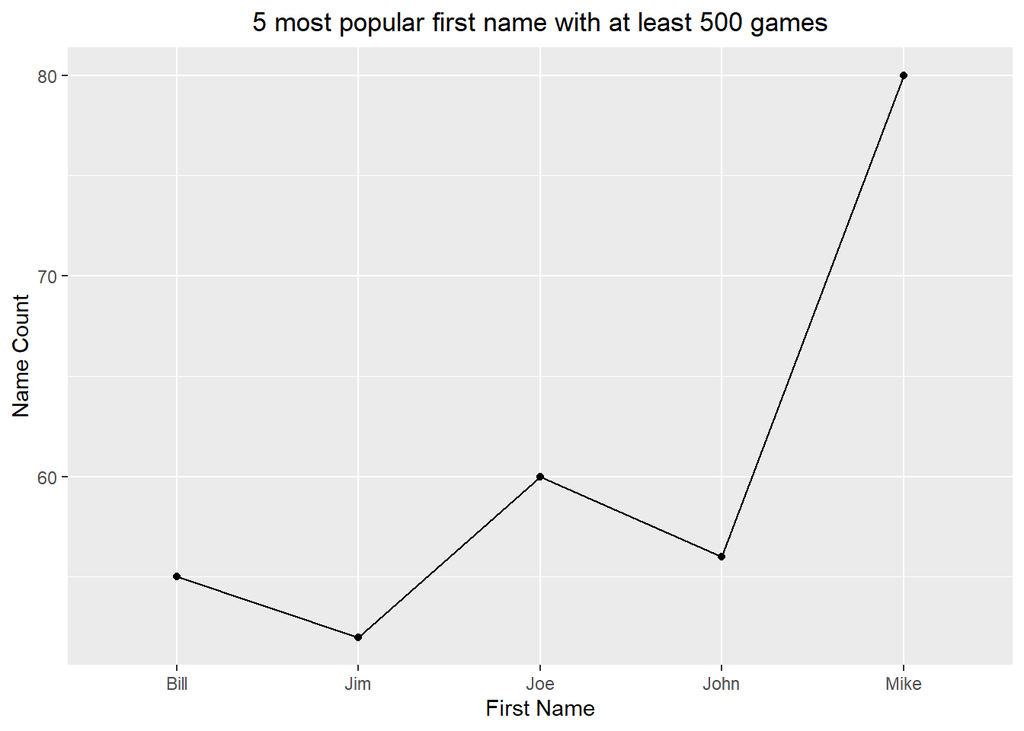

```r
ggplot(data = name_count,
       mapping = aes(x = nameFirst, y = n, group = 1)) +
  geom_line() +
  geom_point() +
  labs(
    title = "5 most popular first name with at least 500 games",
    x = "First Name",
    y = "Name Count"
  ) +
  theme(plot.title = element_text(hjust = 0.5))
```

**2) Read the post at http://www.sumsar.net/blog/2016/09/whats-on-the-menu/ and** **follow the steps yourself.**

**(Please include the R code in the RMarkdown file up through the creation of** **the data frame d - a terrible name, by the way.)**

**Would you have plotted any of the graphs on the webpage differently?**

**The author of the blog post found some interesting, or at least amusing,** **things in the data. Replacing the boring “tea”,** **“coffee”, “apple” “banana”, explore the rise or fall of more interesting** **things like noodles, tandoori, curry, sushi and** **kale in the menu.**

```r
menu_data_url <-
  "https://s3.amazonaws.com/menusdata.nypl.org/gzips/2016_09_16_07_00_30_data.tgz"
temp_dir <- tempdir()
curl_download(menu_data_url, file.path(temp_dir, "menu_data.tgz"))
untar(file.path(temp_dir, "menu_data.tgz"), exdir = temp_dir)
dish <- read_csv(file.path(temp_dir, "Dish.csv"))
menu <- read_csv(file.path(temp_dir, "Menu.csv"))
menu_item <- read_csv(file.path(temp_dir, "MenuItem.csv"))
menu_page <- read_csv(file.path(temp_dir, "MenuPage.csv"))
```

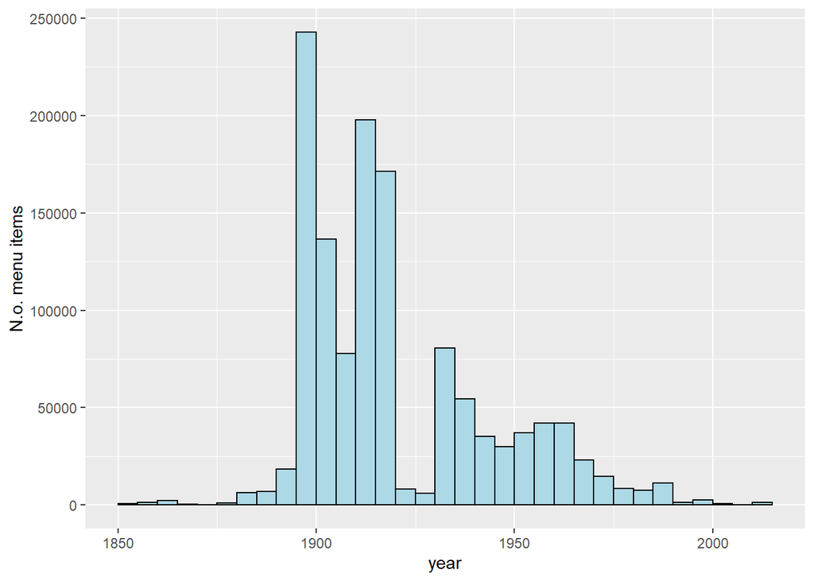

```r
d <- menu_item %>% select( id, menu_page_id, dish_id, price) %>%
  left_join(dish %>% select(id, name) %>% rename(dish_name = name),
            by = c("dish_id" = "id")) %>%
  left_join(menu_page %>% select(id, menu_id),
            by = c("menu_page_id" = "id")) %>%
  left_join(menu %>% select(id, date, place, location),
            by = c("menu_id" = "id")) %>%
  mutate(year = lubridate::year(date)) %>%
  filter(!is.na(year)) %>%
  filter(year > 1800 & year <= 2016) %>%
  select(year, location, menu_id, dish_name, price, place)




ggplot(d, aes(year)) +
  geom_histogram(binwidth = 5, center = 1902.5, color = "black", fill = "lightblue") +
  scale_y_continuous("N.o. menu items")
```

```r
d$decennium = floor(d$year / 10) * 10
#foods <- c("coffee", "tea", "pancake", "ice cream", "french frie",
#           "french peas", "apple", "banana", "strawberry")

foods <- c("noodle", "tandoori", "curry", "sushi", "kale")

food_over_time <- map_df(foods, function(food) {
  d %>%
    filter(year >= 1900 & year <= 1980) %>%
    group_by(decennium, menu_id) %>%
    summarise(contains_food =
                any(str_detect(dish_name, regex(paste0("\\b", food), ignore_case = TRUE)),
                    na.rm = TRUE)) %>%
    summarise(prop_food = mean(contains_food, na.rm = TRUE)) %>%
    mutate(food = food)
})
# A reusable list of ggplot2 directives to produce a lineplot
food_time_plot <- list(
  geom_line(),
  geom_point(),
  scale_y_continuous("% of menus include",labels = scales::percent,
                     limits = c(0, NA)),
  scale_x_continuous(""),
  facet_wrap(~ food),
  theme_minimal(),
  theme(legend.position = "none"))
```

**Here is my own exploration of the various foods in the list noodles,** **tandoori, curry, sushi, and kale**

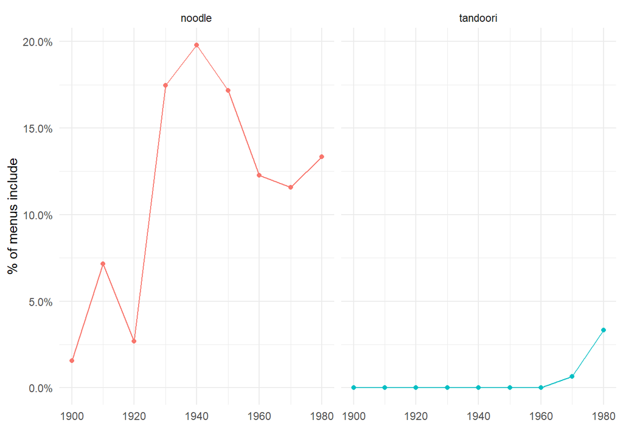

```r
food_over_time %>% filter(food %in% c("noodle", "tandoori")) %>%
  ggplot(aes(decennium, prop_food, color = food)) + food_time_plot
```

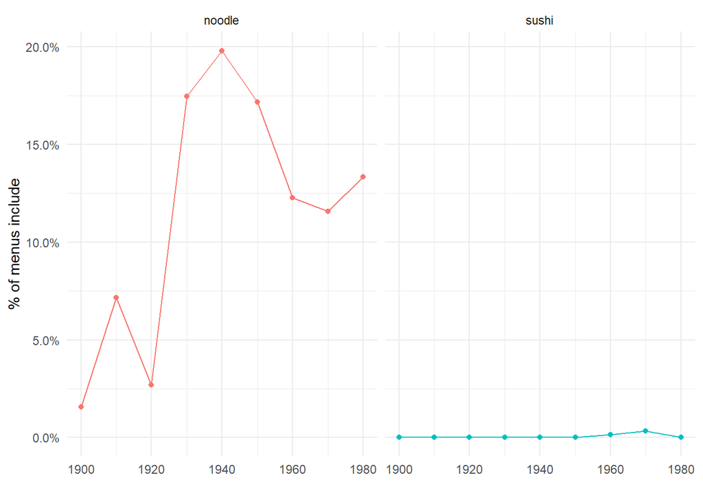

```r
food_over_time %>% filter(food %in% c("noodle", "sushi")) %>%
  ggplot(aes(decennium, prop_food, color = food)) + food_time_plot
```

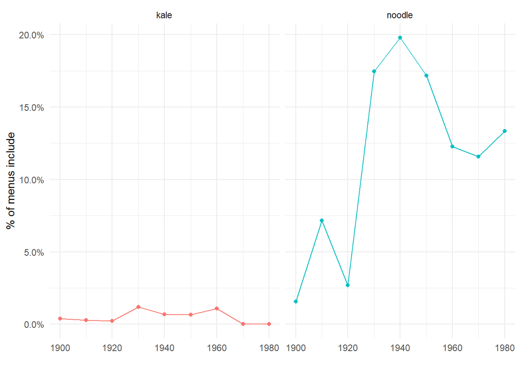

```r
food_over_time %>% filter(food %in% c("noodle", "kale")) %>%
  ggplot(aes(decennium, prop_food, color = food)) + food_time_plot
```

*I would have plotted the above graphs as different colored lines on the same* *plot instead of each one on a different plot* *This first plot demonstrates that tandoori only started getting popular in the* *1980’s*

*the second plot demonstrates that noodes have generally been popular compared* *to sushi*

*In the last plot, it can be seen that Kale at it’s peak comprised less than 2.5%* *of the data*